# Praca domowa nr 2

Agata Pałdyna

18/11/2019

## Opis zadania

Zadanie polegalo na przygotowaniu funkcji, ktora jako argument przyjmuje dowolna funkcje i zwraca funkcje, ktora wykonuje dokladnie to samo, tylko w NSE. Nalezalo przygotowac kilka rozwiazan tego zadania, a nastepnie porownac szybkosc dzialania przy roznych funkcjach i roznych rozmiarach zbioru danych (ktory powinien byc lista lub data.frame)

Czasy dzialania funkcji mierzylam za pomoca funkcji `microbenchmark::microbenchmark` dla 100 powtorzen. Jako czas dzialania funkcji przyjelam mediane z tych powtorzen.

W benchmarku uwzglednilam nastepujace funkcje:

1. min
2. max
3. mean
4. unlist (z use.names = TRUE i use.names = FALSE)
5. lm

Szybkosc dzialania funkcji sprawdzalam na liscie `x` oraz zbiorze danych `iris`.

## Rozwiazania

Udalo mi sie przygotowac dwa rozwiazania tego zadania.

#### Rozwiazanie nr 1

```r
function_NSE1 <- function(input_function) {
  function(input_list, element_1 = NULL, element_2 = NULL, ...) {
    params_list <- substitute(...())
    params_list_len <- length(params_list)

    element_1 <- substitute(element_1)
    element_2 <- substitute(element_2)

    if(class(element_1) == "call") {
      if(class(eval(element_1)) == "formula") {
        input_formula <- element_1
        element_1 <- input_formula[[2]]
        element_2 <- input_formula[[3]]
      }
    }

    x <- NULL
    y <- NULL

    if(!is.null(element_1)) {
      x <- getElement_NSE(input_list, element_1)
    }

    if(!is.null(element_2)) {
      y <- getElement_NSE(input_list, element_2)
    }

    if(!is.null(x) && !is.null(y)) {
      xf <- y
      yf <- x
      x <- as.formula("yf ~ xf")
    }
    else if(is.null(x) && is.null(y)) {
      x <- input_list
    }
    # }

    if(!is.null(x)) {
      if(params_list_len == 0) {
        input_function(x)
      }
      else {
        arguments <- c(list(x), params_list)
        do.call(input_function, arguments)
      }
    }
  }
}
```

#### Rozwiazanie nr 2

```r
function_NSE2 <- function(input_function) {
  function(input_list, element = NULL, env = caller_env(), ...) {
    params_list <- substitute(...())
    params_list_len <- length(params_list)

    s_element <- substitute(element)

    if(class(s_element) == "call") {
      if(class(eval(s_element)) == "formula") {
        input_formula <- enexpr(element)
        data <- enexpr(input_list)
        eval(expr(input_function(!!input_formula, !!data)))
      }
    }
    else {
      x <- NULL

      if(!is.null(s_element)) {
        x <- getElement_NSE(input_list, s_element)
      }

      if(is.null(x)) {
        x <- input_list
      }

      if(!is.null(x)) {
        if(params_list_len == 0) {
          input_function(x)
        }
        else {
          arguments <- c(list(x), params_list)
          do.call(input_function, arguments)
        }
      }
    }
  }
}
```

Rozwiazania te sa dosc podobne, oba korzystaja z funkcji z wykladu `getElement_NSE()`, w obu mozna podawac dodatkowe parametry do funkcji takie jak np. `use.names = FALSE` dla funkcji `unlist()` czy `na.rm = TRUE` dla funkcji `min()`. Roznia sie jedynie obsluga formul. Wezmy na przyklad funkcje `lm()`. W przypadku **Rozwiazania nr 1** mozemy podac zmienna objasniana i tylko jedna zmienna objasniajaca, ale mozemy to zrobic na dwa sposoby, podajac zmienne oddzielnie lub jako formule (patrz przyklady nizej).

```r
x <- list(a = c(1, 2, 30), b = c(2, 1, 5), c = c(33, 21, 2))
lm_NSE <- function_NSE1(lm)
```

```r
# Sposob 1
lm_NSE(x, b, a)
```

```
##
## Call:
## input_function(formula = x)
##
## Coefficients:
## (Intercept)           xf
##      1.3272       0.1218
```

```r
# Sposob 2
lm_NSE(x, b ~ a)
```

```
##
## Call:
## input_function(formula = x)
##
## Coefficients:
## (Intercept)           xf
##      1.3272       0.1218
```

Natomiast w przypadku **Rozwiazania nr 2** nie ma ograniczenia co do liczby zmiennych objasniajacych, a obsluga formuly zostala calkowicie wydzielona jako osobny fragment kodu.

```r
x <- list(a = c(1, 2, 30), b = c(2, 1, 5), c = c(33, 21, 2))
lm_NSE <- function_NSE2(lm)
lm_NSE(x, b ~ a + c)
```

```
##
## Call:
## input_function(formula = b ~ a + c, data = x)
##
## Coefficients:
## (Intercept)            a            c
##     -1.5426       0.2114       0.1009
```

W **Rozwiazaniu nr 1** skorzystalam tylko z bazowego NSE, natomiast w **Rozwiazaniu nr 2** poza bazowym NSE skorzystalam rowniez z funkcji `enexpr()` z pakietu `rlang`.

## Porownanie szybkosci dzialania

```r
# Dane
x <- list(a = c(1, 2, 30), b = c(2, 1, 5), c = c(33, 21, 2))
```

Wyniki przedstawiaja ponizsze wykresy:

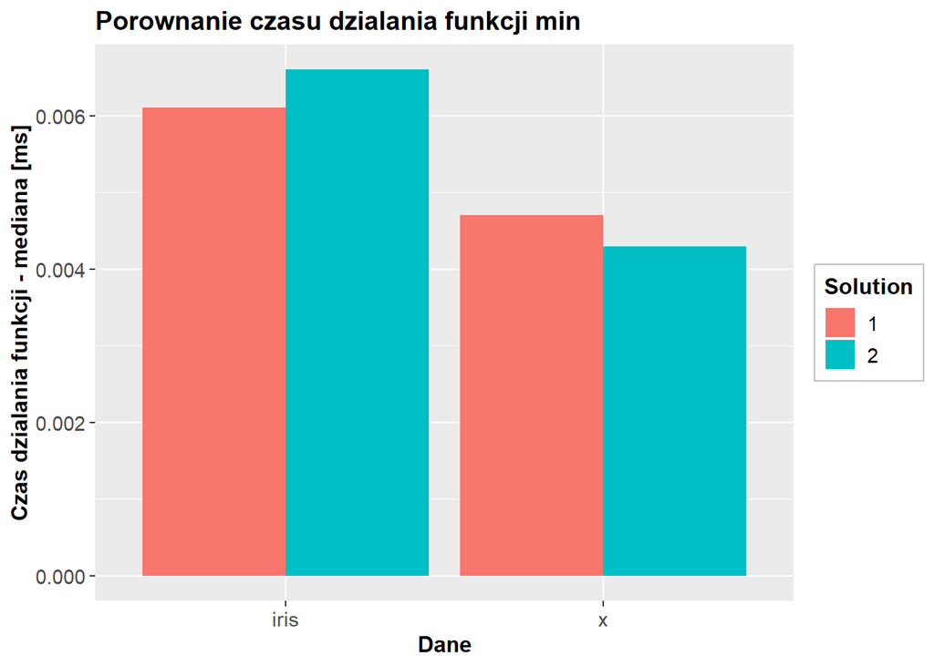

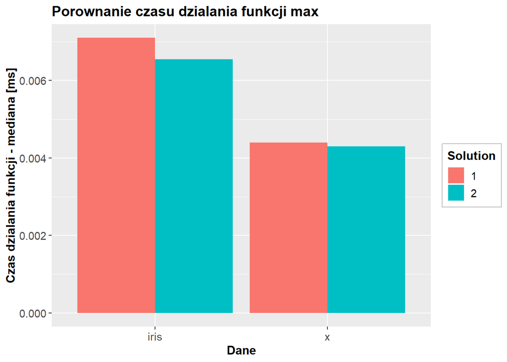

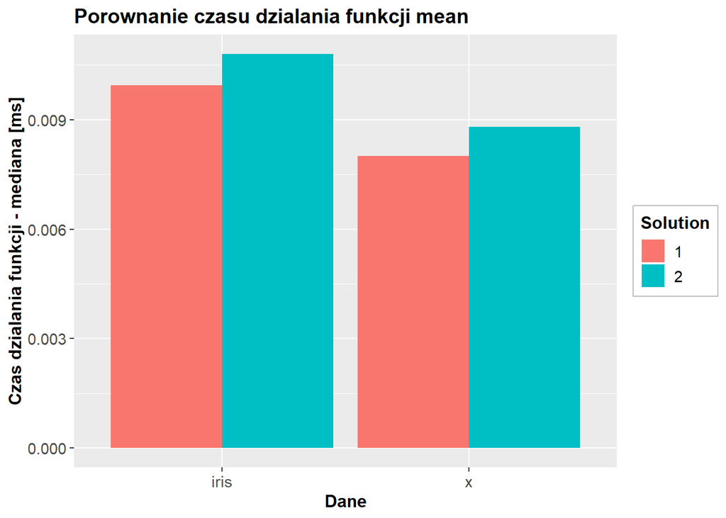

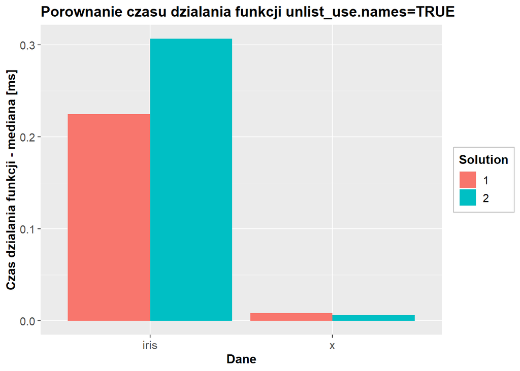

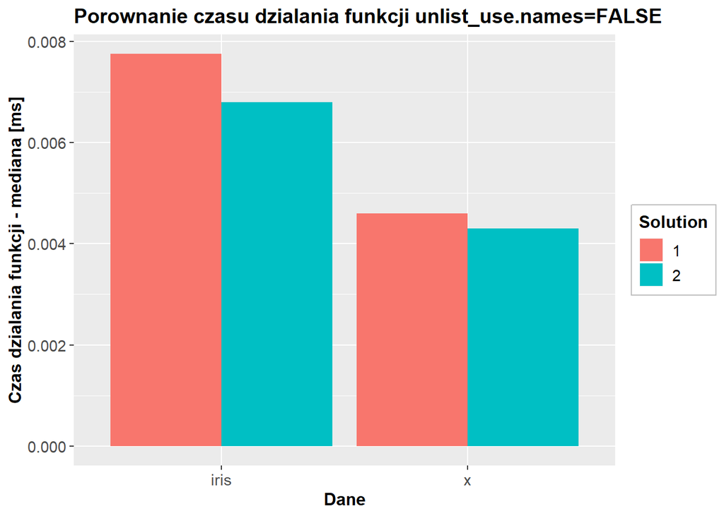

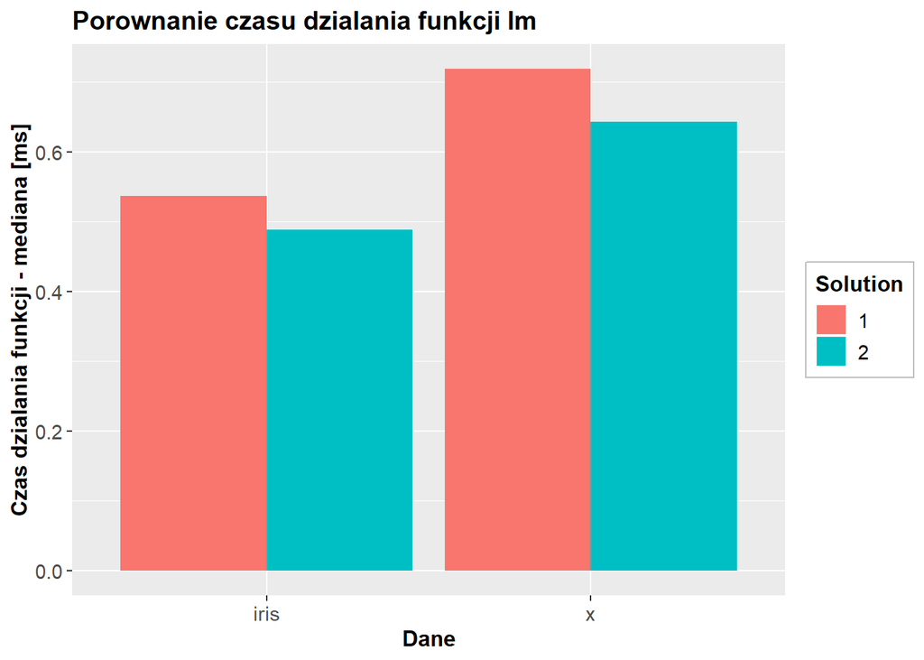

Dokladniejsze wyniki mozna sprawdzic w tabeli:

| Function | Data | Solution | Time |
| --- | --- | --- | --- |
| min | x | 1 | 0.00470 |
| min | x | 2 | 0.00430 |
| min | iris | 1 | 0.00610 |
| min | iris | 2 | 0.00660 |
| max | x | 1 | 0.00440 |
| max | x | 2 | 0.00430 |
| max | iris | 1 | 0.00710 |
| max | iris | 2 | 0.00655 |
| mean | x | 1 | 0.00800 |
| mean | x | 2 | 0.00880 |
| mean | iris | 1 | 0.00995 |
| mean | iris | 2 | 0.01080 |
| unlist_use.names=TRUE | x | 1 | 0.00830 |
| unlist_use.names=TRUE | x | 2 | 0.00620 |
| unlist_use.names=TRUE | iris | 1 | 0.22490 |
| unlist_use.names=TRUE | iris | 2 | 0.30655 |
| unlist_use.names=FALSE | x | 1 | 0.00460 |
| unlist_use.names=FALSE | x | 2 | 0.00430 |
| unlist_use.names=FALSE | iris | 1 | 0.00775 |
| unlist_use.names=FALSE | iris | 2 | 0.00680 |
| lm | x | 1 | 0.71875 |
| lm | x | 2 | 0.64360 |
| lm | iris | 1 | 0.53675 |
| lm | iris | 2 | 0.48800 |